# Analyze WeRateDogs Tweets

Helen

## Introduction

This report communicates the insights and displays the visualization(s) produced from my wrangled data about WeRateDogs Twitter achive taken from 3 different sources

## About WE RATE DOGS

The dataset used for wrangling (and analyzing and visualizing) is the tweet archive of Twitter user @dog_rates, also known as WeRateDogs. WeRateDogs is a Twitter account that rates people's dogs with a humorous comment about the dog. These ratings almost always have a denominator of 10. The numerators, though? Almost always greater than 10. 11/10, 12/10, 13/10, etc. Why? Because "they're good dogs Brent." WeRateDogs has over 4 million followers and has received international media coverage.

WeRateDogs downloaded their Twitter archive and sent it to Udacity via email exclusively for student like us to use in this project. This archive contains basic tweet data (tweet ID, timestamp, text, etc.) for all 5000+ of their tweets as they stood on August 1, 2017.

## Insights

This section will be a short write up with images to explain some insights from the analysis and visualization of wrangled data.

**Insight 1: Most commonly predicted breeds**

- The most commonly predicted dog breeds is golden retriever. It is predicted more than 120 times. Followed by labrador retreiver and pembroke.

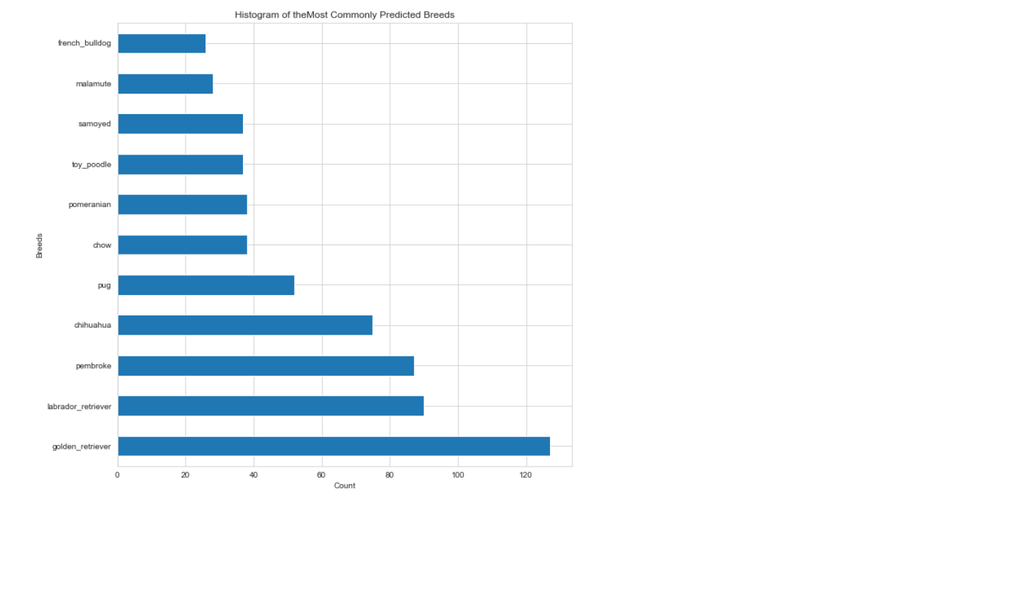

**Insight 2 : Most Tweeted Dog Stages**

- Pupper is having highest tweets among other dog stage.

**Insight 3 : Correlation between Retweet Count and Favorite Count.**

- There is a positive correlation between favorites and retweeting.

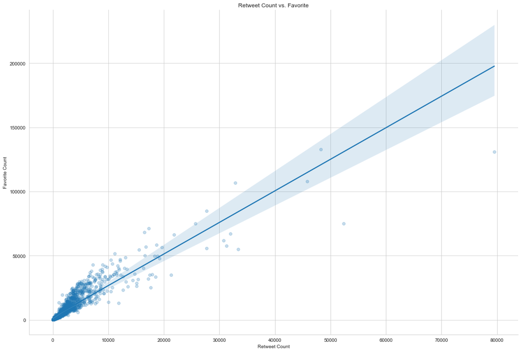

**Insight 4 : The highest ratings do not receive the most retweets.**

- From the graph below, we can see that highest ratings do not receive the most retweets.

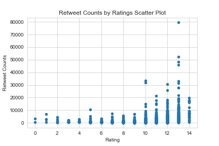

## Conclusion

From the analysis, the most commonly predicted dog breed is golden retriver. Pupper is having highest tweets among other dog stage. From the scatter plot graph, we can see that There is a positive correlation between favorites and retweeting. One interesting finding is the highest rating tweet does not receive the most retweets.

In short, it is really interesting to draw some facts and summary from this data wrangling process. The data can be wrangled again in order to make it more reliable and useful.